# Atividade_3_5_Final_Mariana_Faitanin

Mariana Faitanin

23/05/2022

#Atividade final da disciplina Ciência colaborativa

ATIVIDADE 3

##Para iniciar as atividades, é necessário a instalação de alguns pacotes.

```r
require(tidyverse)
require(rgbif)
require(dplyr)
require(ggmap)
```

```r
require(maps)
require(mapdata)
require(ggplot2)
require(yaml)
```

```r
# checar funcoes
?occ_data

# baixar ocorrencias
trigo_gbif <- occ_data(scientificName = "Trigoniodendron spiritusanctense",
                      hasCoordinate = TRUE,
                      hasGeospatialIssue=FALSE)

# dimensoes
dim(trigo_gbif)
```

```r
dim(trigo_gbif$data)
```

```
## [1] 57 80
```

#Após conferir o número de linhas e colunas do seu objeto, teremos que conferir o nome das colunas dentro desse dataset

```r
# checar campos
trigo_gbif$data %>% names
```

```
##  [1] "key"                    "scientificName"         "decimalLatitude"
##  [4] "decimalLongitude"       "issues"                 "datasetKey"
##  [7] "publishingOrgKey"       "installationKey"        "publishingCountry"
## [10] "protocol"               "lastCrawled"            "lastParsed"
## [13] "crawlId"                "hostingOrganizationKey" "basisOfRecord"
## [16] "occurrenceStatus"       "taxonKey"               "kingdomKey"
## [19] "phylumKey"              "classKey"               "orderKey"
## [22] "familyKey"              "genusKey"               "speciesKey"
## [25] "acceptedTaxonKey"       "acceptedScientificName" "kingdom"
## [28] "phylum"                 "order"                  "family"
## [31] "genus"                  "species"                "genericName"
## [34] "specificEpithet"        "taxonRank"              "taxonomicStatus"
## [37] "iucnRedListCategory"    "dateIdentified"         "elevation"
## [40] "elevationAccuracy"      "stateProvince"          "year"
## [43] "month"                  "day"                    "eventDate"
## [46] "modified"               "lastInterpreted"        "license"
## [49] "isInCluster"            "datasetName"            "recordedBy"
## [52] "identifiedBy"           "inCluster"              "geodeticDatum"
## [55] "class"                  "countryCode"            "country"
## [58] "rightsHolder"           "recordNumber"           "identifier"
## [61] "municipality"           "locality"               "collectionCode"
## [64] "gbifID"                 "language"               "occurrenceID"
## [67] "type"                   "catalogNumber"          "institutionCode"
## [70] "ownerInstitutionCode"   "occurrenceRemarks"      "networkKeys"
## [73] "otherCatalogNumbers"    "fieldNotes"             "individualCount"
## [76] "preparations"           "verbatimEventDate"      "bibliographicCitation"
## [79] "continent"              "name"
```

```r
names(trigo_gbif)
```

```
## [1] "meta" "data"
```

#Aqui continuamos selecionando e validando algumas variáveis do banco de dados para essa e análises futuras. Por exemplo: coordenadas, localidade, nome da base de dados etc.

```r
trigo_gbif1 <- trigo_gbif$data %>%
  dplyr::select(scientificName, acceptedScientificName, decimalLatitude, decimalLongitude,
         issues, basisOfRecord, occurrenceStatus, rightsHolder,
         datasetName, recordedBy, locality)
```

```r
trigo_gbif1 <- trigo_gbif1 %>%
  distinct()
```

#Para identificar todos os valores únicos presente nos dados, vamos aplicar a função unique a cada coluna com um loop na função lapply.

```r
# checar niveis dos fatores
lapply(trigo_gbif1, unique)
```

```
## $scientificName
## [1] "Trigoniodendron spiritusanctense E.F.Guim. & Miguel"
##
## $acceptedScientificName
## [1] "Trigoniodendron spiritusanctense E.F.Guim. & Miguel"
##
## $decimalLatitude
##  [1] -21.50000 -21.34055 -21.38667 -21.38667 -21.40722 -20.17921 -20.75191
##  [8] -21.29694 -21.39139 -21.37556 -21.32556 -21.32167 -21.55472 -21.37944
## [15] -19.14457 -19.86667
##
## $decimalLongitude
##  [1] -41.50000 -41.26389 -41.08417 -41.08417 -41.08667 -40.31849 -41.23164
##  [8] -41.09028 -41.09444 -41.91806 -41.10000 -41.11972 -41.20417 -41.08222
## [15] -40.06568 -40.53333
```

[output cut: 71 more lines]

#A partir daqui faremos uma checagem mais detalhada e minuciosa dos nossos dados. Inicialmente, iremos validar as coordenadas geográficas. #ATEÇÃO:Para essa etapa sera necerrário a utilização dos pacotes “bcd” e “CoordinateCleaner”.

```r
library(bdc)
library(CoordinateCleaner)

# checar coordenadas válidas
check_pf <-
  bdc::bdc_coordinates_outOfRange(
    data = trigo_gbif1,
    lat = "decimalLatitude",
    lon = "decimalLongitude")
```

```
##
## bdc_coordinates_outOfRange:
## Flagged 0 records.
## One column was added to the database.
```

#O próximo passo será checar coordenadas válidas e próximas a capitais. A realização dessa etapa é importante e necessária, pois alguns pesquisadores quando não coleta a coordenada no dia do campo acaba colocando o coordenada “padrão” para o fragmento ou a coordenada do municipio.

```r
cl <- trigo_gbif1 %>%
  select(acceptedScientificName, decimalLatitude, decimalLongitude) %>%
  rename(decimallongitude = decimalLongitude,
         decimallatitude = decimalLatitude,
         scientificName = acceptedScientificName) %>%
  as_tibble() %>%
  mutate(val = cc_val(., value = "flagged"),
         sea = cc_sea(., value = "flagged"),
         capital = cc_cap(., value = "flagged"))
```

```
## Testing coordinate validity
```

```
## Flagged 0 records.
```

```
## Testing sea coordinates
```

```
## Flagged 0 records.
```

```
## Testing country capitals
```

```
## Flagged 0 records.
```

#A *Trigonopdendron spirictusantensis* é uma espécies vegetal que ocorre nas florestas estacionais do Espirito Santo e Rio de Janeiro. Não foi encontrado nenhum ponto além desses estados.

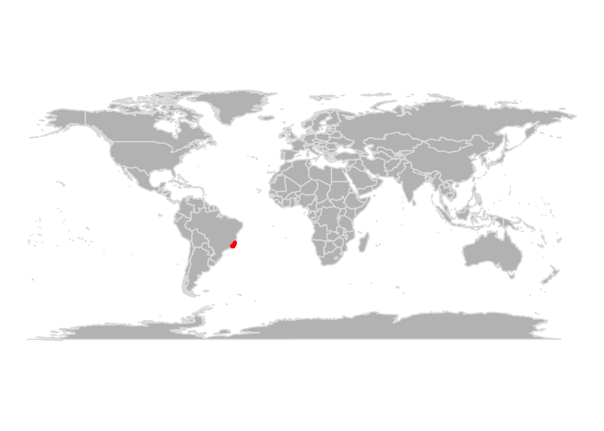

```r
# verificar coordenadas com flags

# capitais (padrão é um raio de 10km)
cl %>%
  rename(decimalLongitude = decimallongitude,
         decimalLatitude = decimallatitude) %>%
  bdc::bdc_quickmap(., col_to_map = "capital")
```

#No exemplo dado em aula, a espécie escolhida apresentava pontos de ocorrencia no mar. Como a espécie selecionada para esse trabalho foi uma espécies arbórea e não teve pontos de ocorrência (errado) no mar, não será necessário a checagem e exclusão dos pontos que cairam no mar.

#A partir daqui, iremos criar o mapa com os pontos de ocorrência.

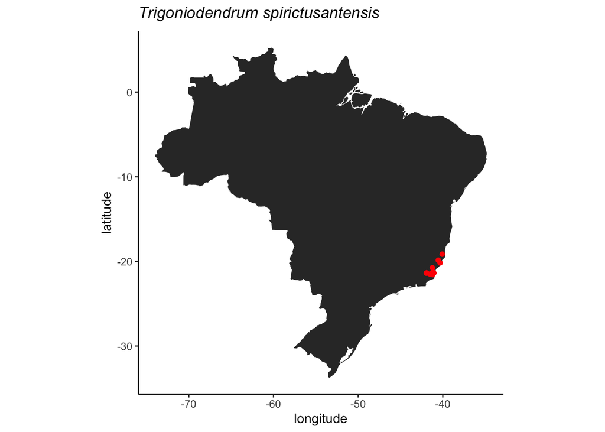

```r
library(ggmap)
library(maps)
library(mapdata)


brasil <- map_data('world',region="Brazil")
# checar pontos

ggplot() +
  geom_polygon(data = brasil, aes(x = long, y = lat, group = group)) +
  coord_fixed() +
  theme_classic() +
  geom_point(data = trigo_gbif1, aes(x = decimalLongitude, y = decimalLatitude), color = "red") +
  labs(x = "longitude", y = "latitude", title = expression(italic("Trigoniodendrum spirictusantensis")))
```

```r
library(tidyverse)
# library(rgbif)

# ocorrencias
# trigo_gbif <- occ_data(scientificName = "Trigoniodendrum spirictusantensis",
#                       hasCoordinate = TRUE,
#                       hasGeospatialIssue = FALSE)

# checar issues
issues_gbif <- trigo_gbif$data$issues %>%
  unique() %>%
  strsplit(., "[,]") %>%
  unlist()

gbif_issues() %>%
  data.frame() %>%
  filter(code %in% issues_gbif)
```

```
##       code                                            issue
## 1  cdround                               COORDINATE_ROUNDED
## 2     cudc                 COUNTRY_DERIVED_FROM_COORDINATES
## 3   gass84                     GEODETIC_DATUM_ASSUMED_WGS84
## 4 muluriiv                           MULTIMEDIA_URI_INVALID
## 5   rdativ                            RECORDED_DATE_INVALID
## 6    osiic OCCURRENCE_STATUS_INFERRED_FROM_INDIVIDUAL_COUNT
## 7   inmano                           INSTITUTION_MATCH_NONE
## 8  diffown                      DIFFERENT_OWNER_INSTITUTION
##                                                                                                                                                             description
## 1                                                                                                               Original coordinate modified by rounding to 5 decimals.
## 2                                                                             The interpreted country is based on the coordinates, not the verbatim string information.
## 3                              Indicating that the interpreted coordinates assume they are based on WGS84 datum as the datum was either not indicated or interpretable.
## 4                                                                                                                      An invalid uri is given for a multimedia object.
## 5                                                                              A (partial) invalid date is given, such as a non existing date, invalid zero month, etc.
## 6                                                                                                        Occurrence status was inferred from the individual count value
## 7                                                                                             The given institution couldn't be matched with any GrSciColl institution.
## 8 The given owner institution is different than the given institution. Therefore we assume it doesn't belong to the institution and we don't link it to the occurrence.
##         type
## 1 occurrence
## 2 occurrence
## 3 occurrence
## 4 occurrence
## 5 occurrence
## 6 occurrence
## 7 occurrence
## 8 occurrence
```

```r
# selecionar variaveis
trigo <- trigo_gbif$data %>%
  dplyr::select(scientificName, decimalLatitude, decimalLongitude) %>%
  distinct()
```

```r
library(leaflet)

# conferir no mapa
trigo %>%
  leaflet() %>%
  addTiles() %>%
  addMarkers(~decimalLongitude,
             ~decimalLatitude)
```

[interactive chart not shown]

[output not shown]

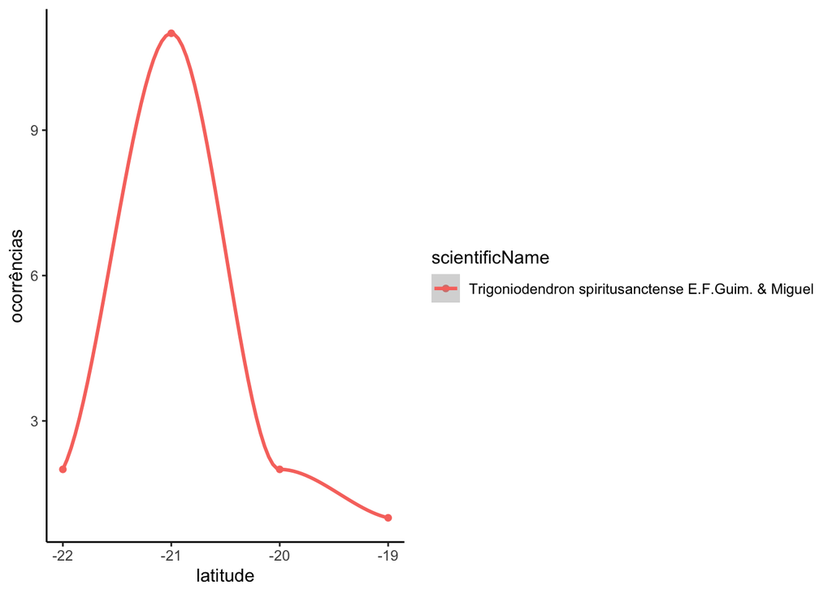

```r
trigo %>%
  mutate(lat = round(decimalLatitude)) %>%
  group_by(lat, scientificName) %>%
  summarise(occ = length(scientificName)) %>%
  ggplot(aes(y = occ, x = lat, color = scientificName)) +
    geom_point() +
    geom_smooth() +
    theme_classic() +
    labs(x = "latitude", y = 'ocorrências')
```

#Análise explioratória

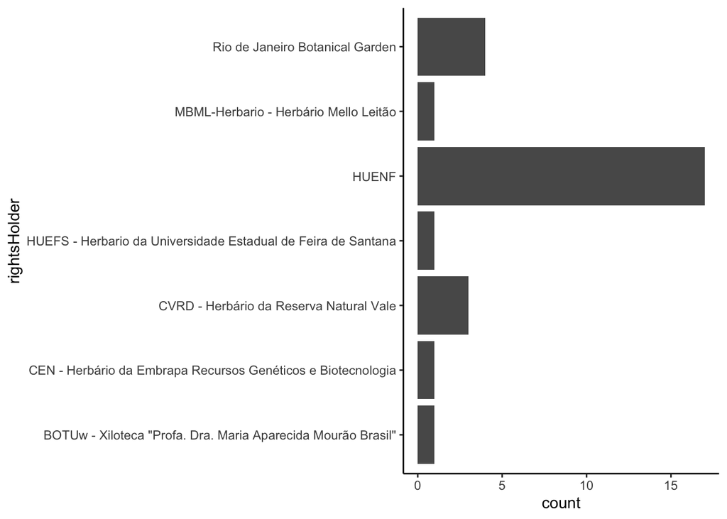

```r
# plot(scientificName~rightsHolder, data=trigo_gbif1)

trigo_gbif1 %>%
  ggplot(aes(y = rightsHolder)) +
    geom_histogram(stat = "count") +
    theme_classic()
```